# Cross Validate Plots

Kevin Lu

December 12, 2017

# 1. Source Cross Validate Functions

```r
source("./Mean Reversion/TMR.003 Pairs Trading Functions.R")
```

# 2. Load Data

```r
pricing_data <- load_data(source = "csv", time_resolution = "300")
```

# 3. Parameter List

Description  
A list of parameters passed to the functions below that describe the mean reversion pairs trading strategy.

Arguments  
time_resolution: The number of seconds that each observation spans. Takes values 300, 900, 1800, 7200, 14400, and 86400.  
quote_currency: A string indicating the quote currency of the currency pairs. Takes values “USDT” or “BTC”.  
cointegration_test: A string indicating whether the Engle-Granger method or distance method is used to test for cointegration. Takes values “eg”, “tls”, or “distance”.  
adf_threshold: The threshold for the ADF test statistic. Pairs below this threshold are selected when using the Engle-Granger method.  
distance_threshold: The threshold for the rmse of the coins normalized prices. Pairs below this threshold are selected when using the distance method.  
train_window: A lubridate period object representing the length of time the train set covers.  
test_window: A lubridate period object representing the length of time the the test set covers.  
model_type: A string indicating whether raw prices or log prices should be used. Takes value “raw” or “log”.  
regression_type: A string indicating whether OLS, TLS, or a non-parametric regression should be used. Takes values “ols”, “tls”, or “non-parametric”.  
spread_type: A string indicating whether the regression uses a rolling or fixed window. Takes value “rolling” or “fixed”.  
rolling_window: The number of observations used in the lookback window of a rolling linear regression.  
signal_logic: A string indicating which logic to use to generate signals. Takes values “scaled” or “discrete”.  
signal_scaled_enter: The z-score threshold indicating the z-score that the signal is fully scaled in when the signal logic is scaled.  
signal_discrete_enter: The z-score threshold for entering a position when the signal logic is discrete.  
signal_discrete_exit: The z-score threshold for exiting a position when the signal logic is discrete.  
signal_stop: A threshold for the spread z-score beyond which the strategy stops trading the coin pair.  
signal_reenter: A boolean indicating whether the strategy should reenter positions after exceeding the signal_stop threshold once the spread z-score returns to a reasonable range.  
signal_reenter_threshold: The z-score threshold for reentering a position if signal_reenter is TRUE. pair_allocation: A string indicating whether the capital allocation to the coin pairs should be equal or weighted. Takes values “equal”, “weighted”, and “scaled”.  
pair_allocation_scaling: A double indicating the volatility scaling applied to the cointegration stat when the pair allocation is scaled. Higher numbers are associated with greater weight being placed on coin pairs with a high cointegration stat.

# 4. Set Parameters

```r
params <- list(time_resolution = 300,
               quote_currency = "USDT",
               cointegration_test = "eg",
               adf_threshold = -4.0,
               distance_threshold = 0.00,
               train_window = days(30),
               test_window = days(20),
               model_type = "raw",
               regression_type = "ols",
               spread_type = "rolling",
               rolling_window = 1440,
               signal_logic = "scaled",
               signal_scaled_enter = 3.0,
               signal_discrete_enter = 3.0,
               signal_discrete_exit = 0.2,
               signal_stop = 4.5,
               signal_reenter = TRUE,
               signal_reenter_threshold = 2.00,
               pair_allocation = "equal",
               pair_allocation_scaling = 1.00)
number_pairs <- 1
```

# 5. Cross Validation September 2017

```r
plot_many(pricing_data = pricing_data,
          cutoff_date = "2017-09-01",
          params = params,
          number_pairs = number_pairs)
```

```
## [1] "No coin pairs selected."
```

# 6. Cross Validation August 2017

```
## # A tibble: 5 x 3
##      coin_y    coin_x cointegration_stat
##       <chr>     <chr>              <dbl>
## 1  USDT_ETH  USDT_ZEC          -6.054465
## 2  USDT_ZEC  USDT_ETH          -5.967695
## 3 USDT_DASH  USDT_XMR          -5.299587
## 4  USDT_XMR USDT_DASH          -5.189520
## 5  USDT_LTC  USDT_ZEC          -4.412000
## [1] "Creating plots for USDT_ETH and USDT_ZEC."
## [1] "Using train set from 2017-07-02 to 2017-08-01."
## [1] "Using test set from 2017-08-01 to 2017-08-21."
```

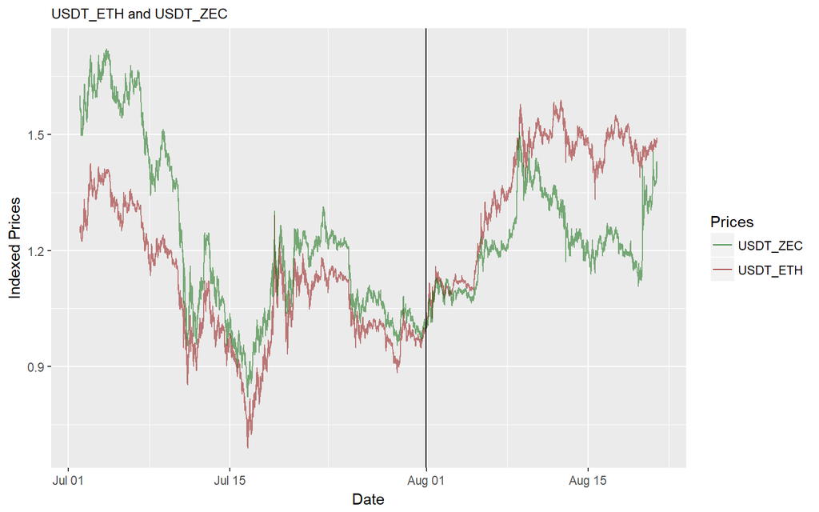

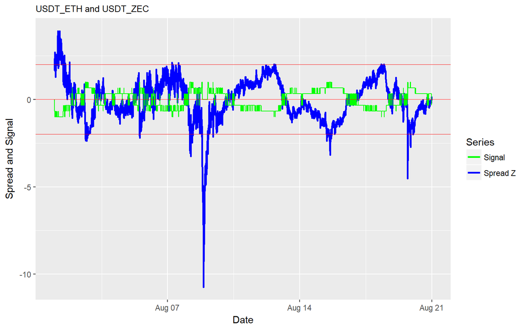

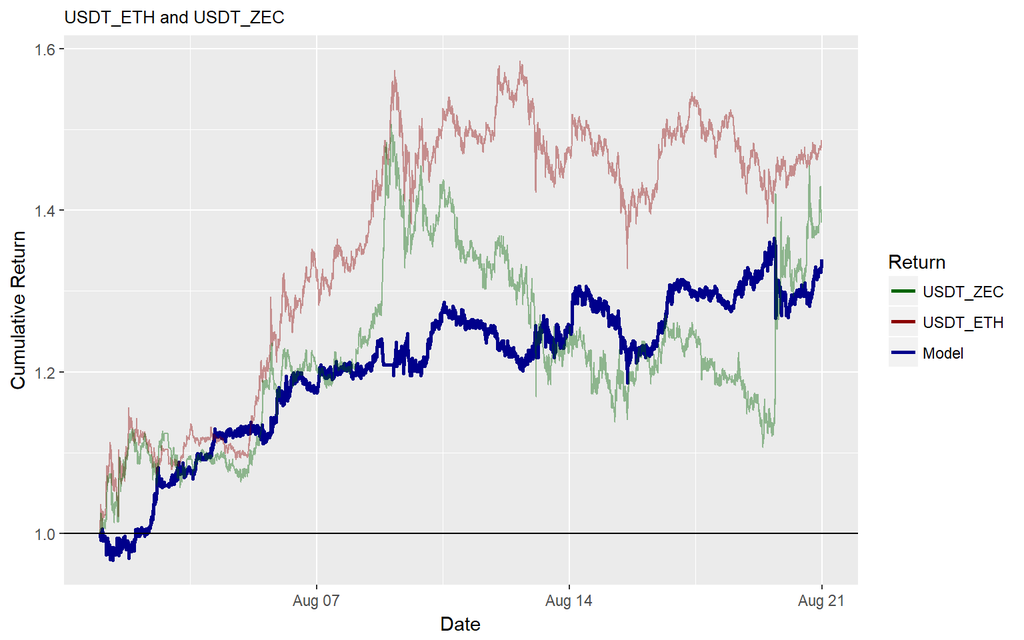

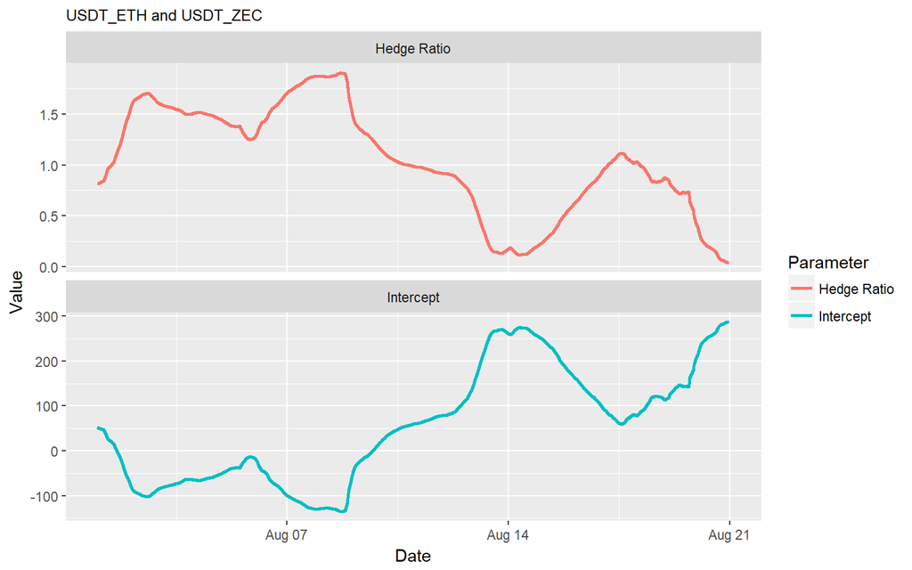

```
## [1] "Creating plot for overall strategy."
```

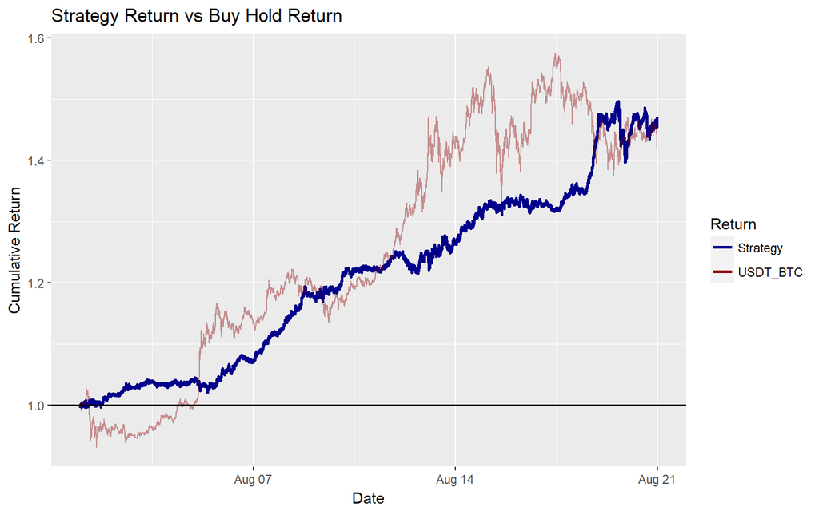

```r
plot_many(pricing_data = pricing_data,
          cutoff_date = "2017-08-01",
          params = params,
          number_pairs = number_pairs)
```

# 7. Cross Validation July 2017

```
## # A tibble: 4 x 3
##      coin_y   coin_x cointegration_stat
##       <chr>    <chr>              <dbl>
## 1  USDT_BTC USDT_XMR          -5.631816
## 2  USDT_XMR USDT_BTC          -5.479049
## 3 USDT_DASH USDT_ZEC          -4.102562
## 4 USDT_DASH USDT_LTC          -4.007783
## [1] "Creating plots for USDT_BTC and USDT_XMR."
## [1] "Using train set from 2017-06-01 to 2017-07-01."
## [1] "Using test set from 2017-07-01 to 2017-07-21."
```

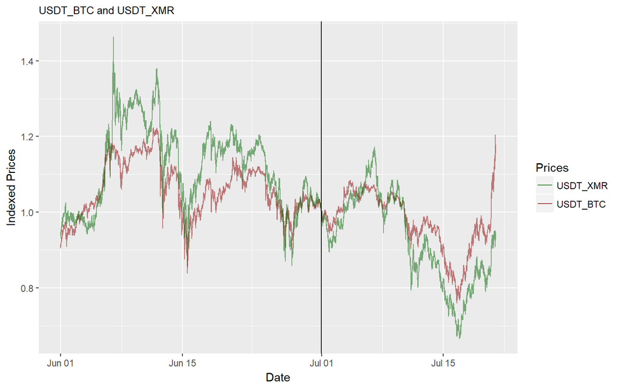

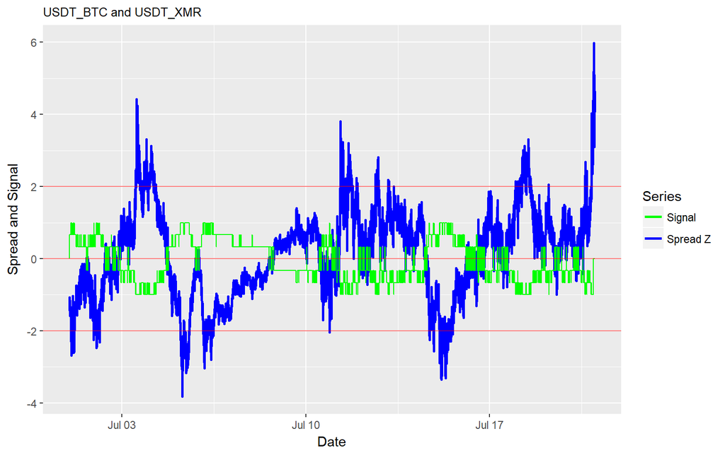

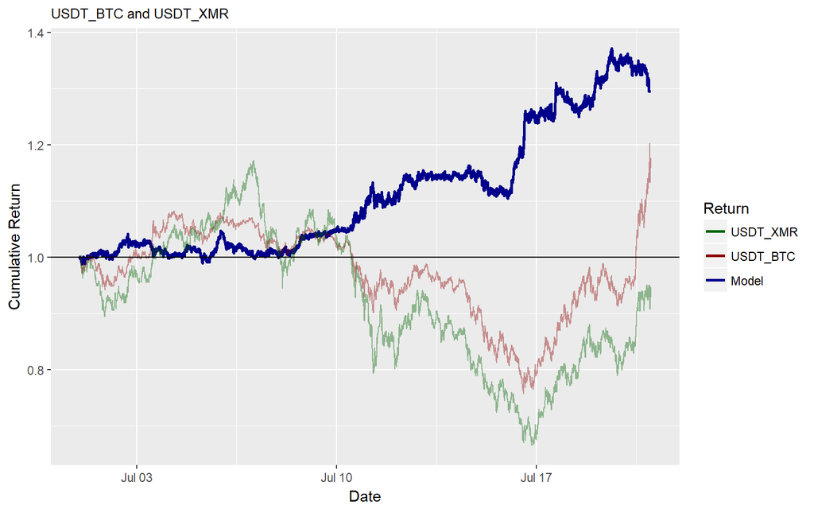

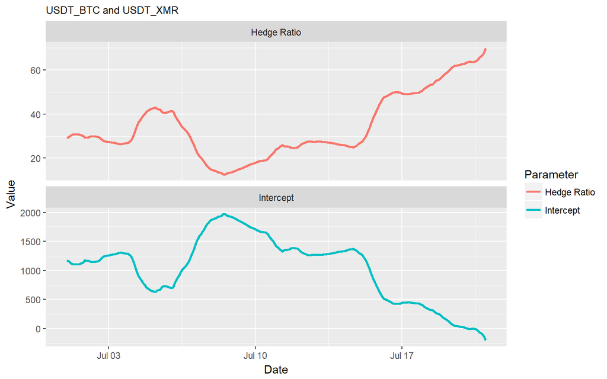

```
## [1] "Creating plot for overall strategy."
```

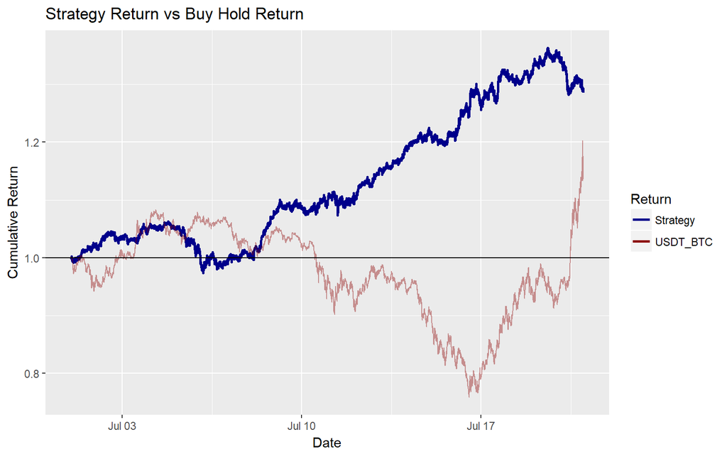

```r
plot_many(pricing_data = pricing_data,
          cutoff_date = "2017-07-01",
          params = params,
          number_pairs = number_pairs)
```

# 8. Cross Validation June 2017

```
## # A tibble: 11 x 3
##       coin_y    coin_x cointegration_stat
##        <chr>     <chr>              <dbl>
##  1 USDT_DASH  USDT_XMR          -6.576085
##  2  USDT_XMR USDT_DASH          -6.568115
##  3 USDT_DASH  USDT_ZEC          -6.264925
##  4  USDT_ZEC USDT_DASH          -6.037114
##  5  USDT_XMR  USDT_ZEC          -5.616863
##  6  USDT_ZEC  USDT_XMR          -5.376518
##  7  USDT_ZEC  USDT_ETH          -4.849517
##  8  USDT_ETH  USDT_ZEC          -4.540834
##  9  USDT_XMR  USDT_BTC          -4.338487
## 10  USDT_BTC  USDT_XMR          -4.198414
## 11 USDT_DASH  USDT_ETH          -4.131498
## [1] "Creating plots for USDT_DASH and USDT_XMR."
## [1] "Using train set from 2017-05-02 to 2017-06-01."
## [1] "Using test set from 2017-06-01 to 2017-06-21."
```

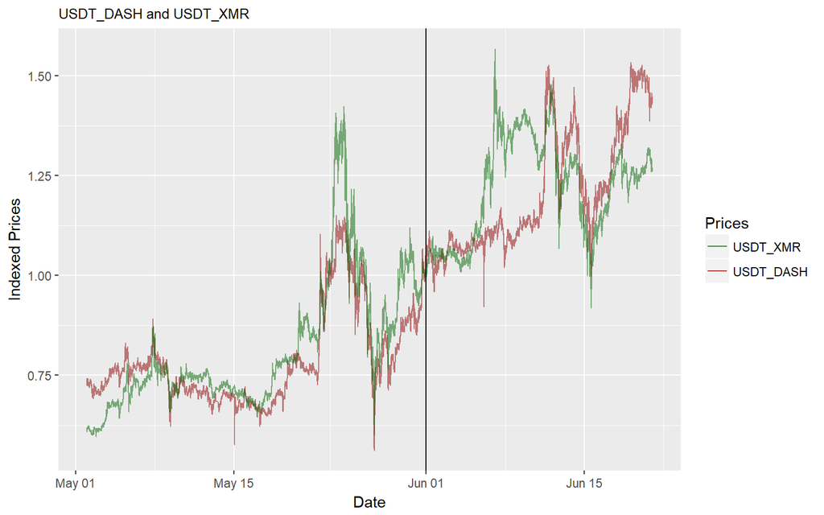

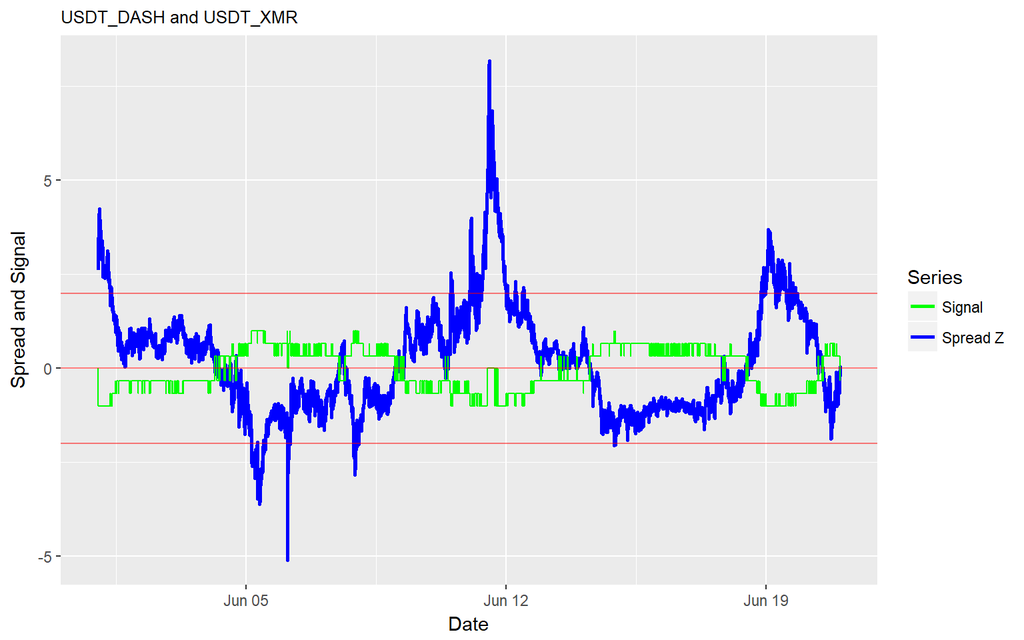

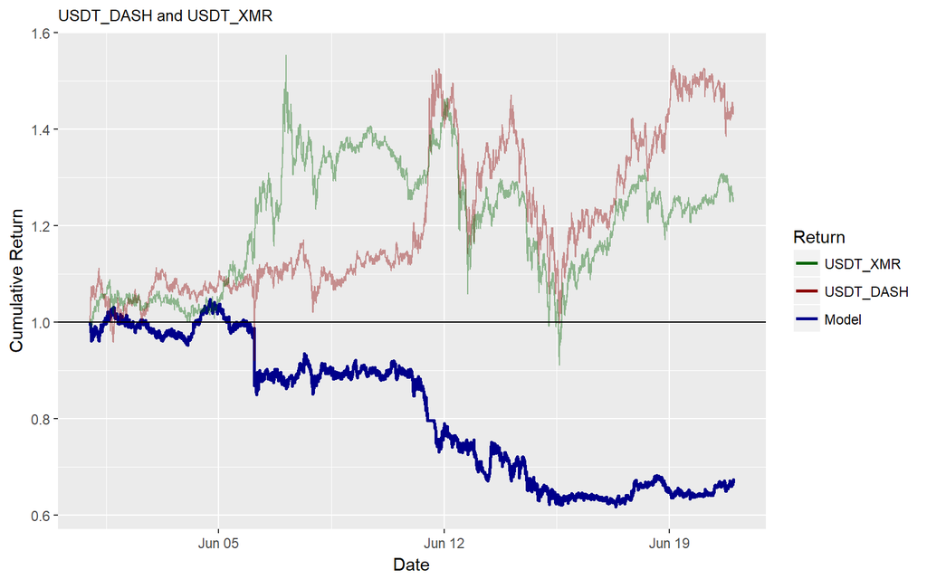

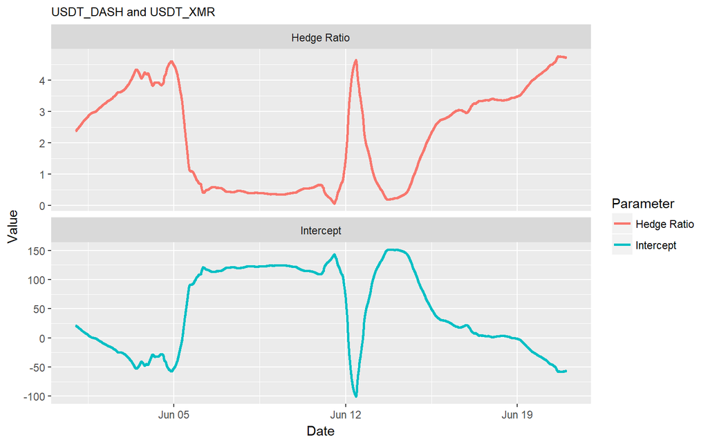

```
## [1] "Creating plot for overall strategy."
```

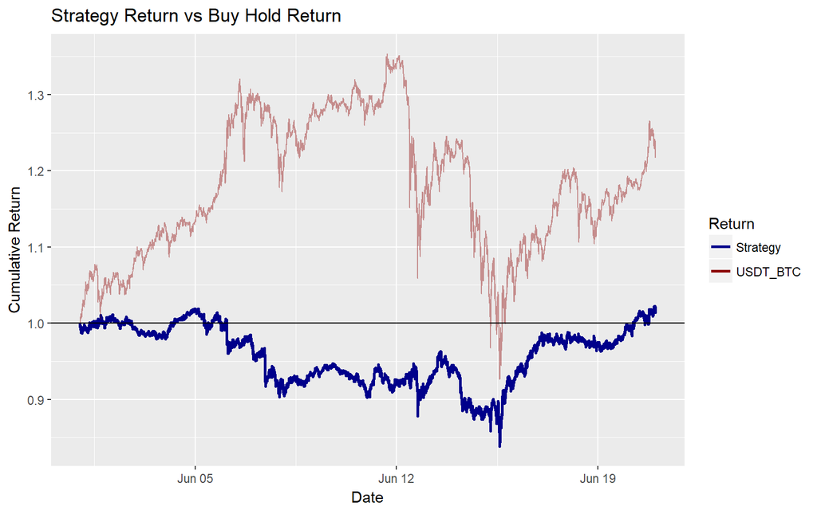

```r
plot_many(pricing_data = pricing_data,
          cutoff_date = "2017-06-01",
          params = params,
          number_pairs = number_pairs)
```

# 9. Cross Validation May 2017

```
## # A tibble: 9 x 3
##      coin_y    coin_x cointegration_stat
##       <chr>     <chr>              <dbl>
## 1 USDT_DASH  USDT_ZEC          -5.324670
## 2  USDT_ZEC USDT_DASH          -5.132194
## 3  USDT_XMR  USDT_ZEC          -5.068398
## 4  USDT_ZEC  USDT_XMR          -4.672742
## 5  USDT_XMR  USDT_ETH          -4.555376
## 6 USDT_DASH  USDT_ETH          -4.416835
## 7  USDT_XMR USDT_DASH          -4.262944
## 8  USDT_ZEC  USDT_ETH          -4.088190
## 9 USDT_DASH  USDT_XMR          -4.036158
## [1] "Creating plots for USDT_DASH and USDT_ZEC."
## [1] "Using train set from 2017-04-01 to 2017-05-01."
## [1] "Using test set from 2017-05-01 to 2017-05-21."
```

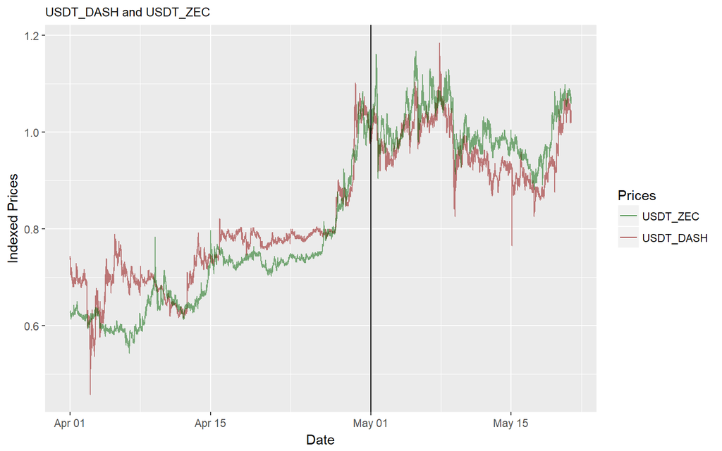

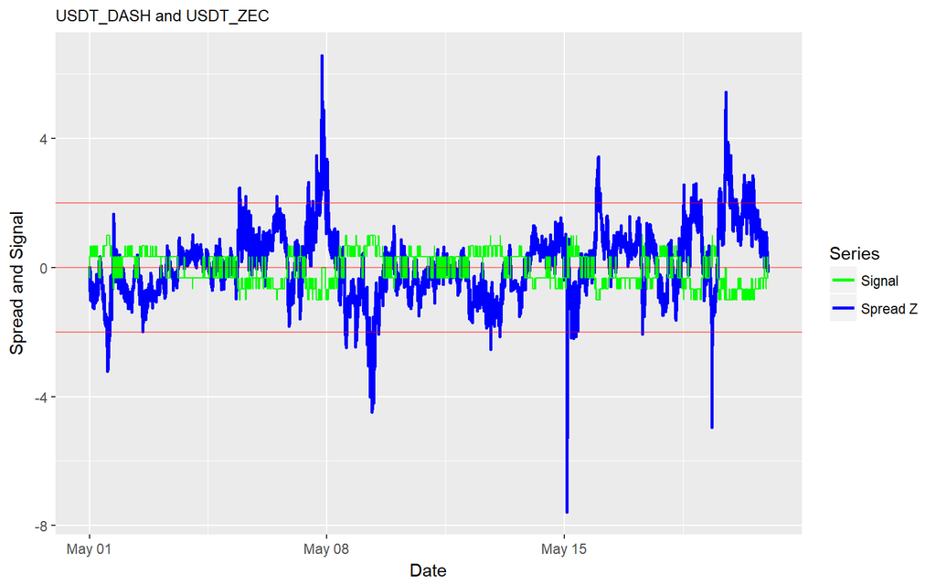

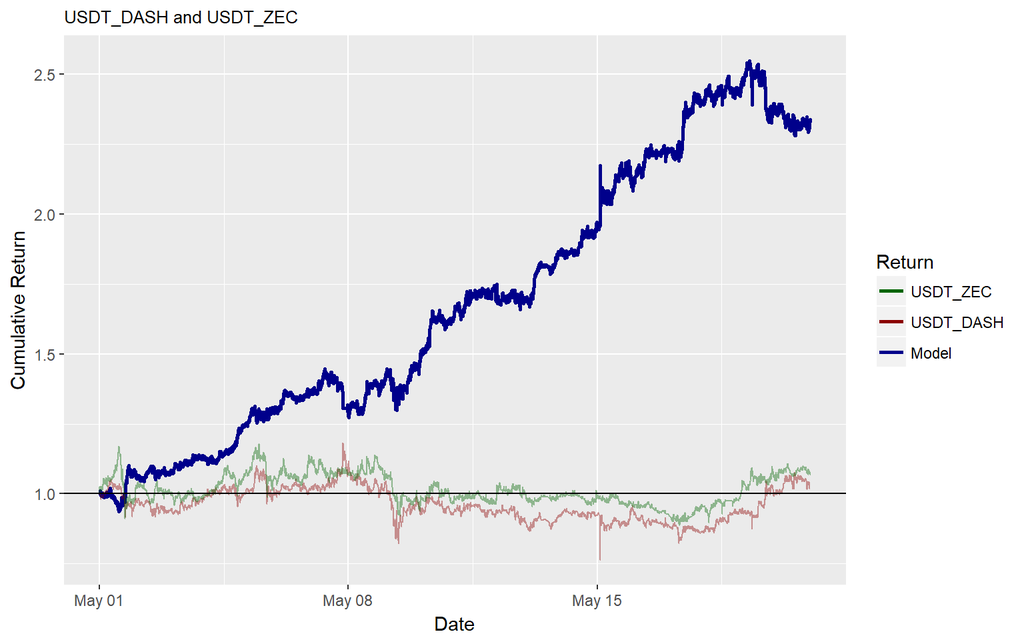

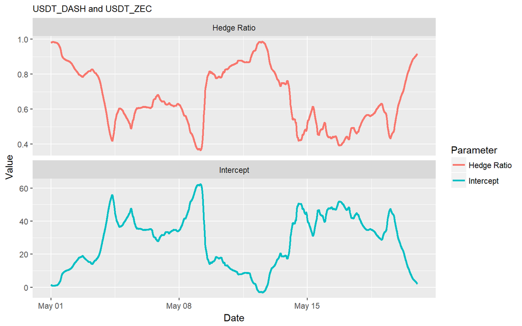

```
## [1] "Creating plot for overall strategy."
```

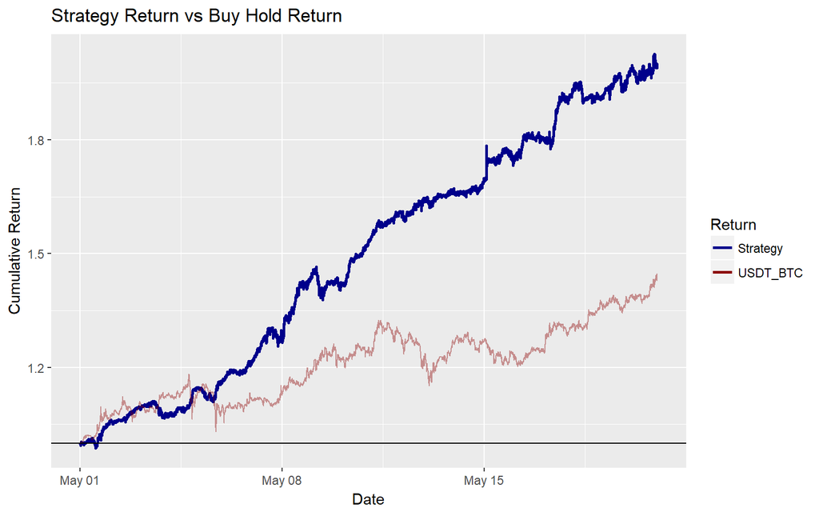

```r
plot_many(pricing_data = pricing_data,
          cutoff_date = "2017-05-01",
          params = params,
          number_pairs = number_pairs)
```

# 10. Cross Validation April 2017

```
## # A tibble: 6 x 3
##      coin_y    coin_x cointegration_stat
##       <chr>     <chr>              <dbl>
## 1  USDT_XMR USDT_DASH          -4.629148
## 2  USDT_ZEC  USDT_BTC          -4.568420
## 3  USDT_BTC  USDT_ZEC          -4.537424
## 4 USDT_DASH  USDT_XMR          -4.520526
## 5  USDT_XMR  USDT_ZEC          -4.418915
## 6  USDT_ZEC  USDT_XMR          -4.347171
## [1] "Creating plots for USDT_XMR and USDT_DASH."
## [1] "Using train set from 2017-03-02 to 2017-04-01."
## [1] "Using test set from 2017-04-01 to 2017-04-21."
```

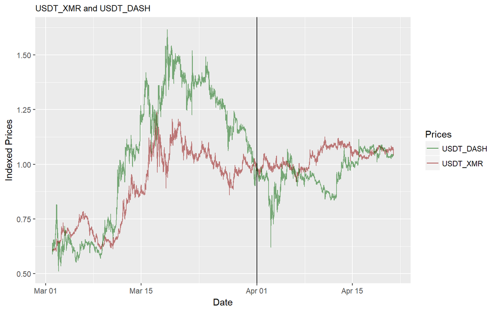

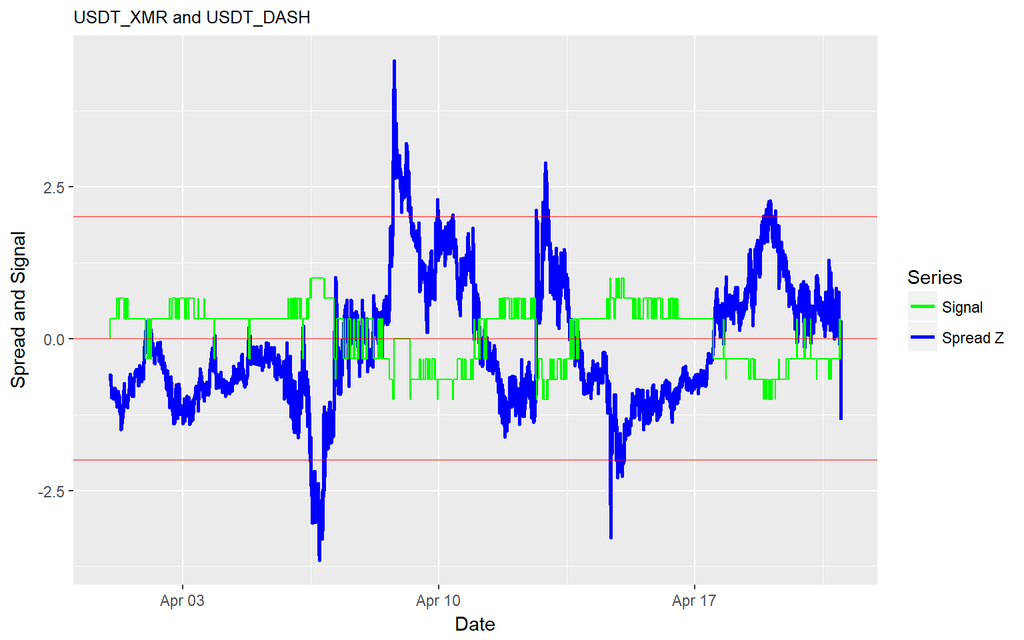

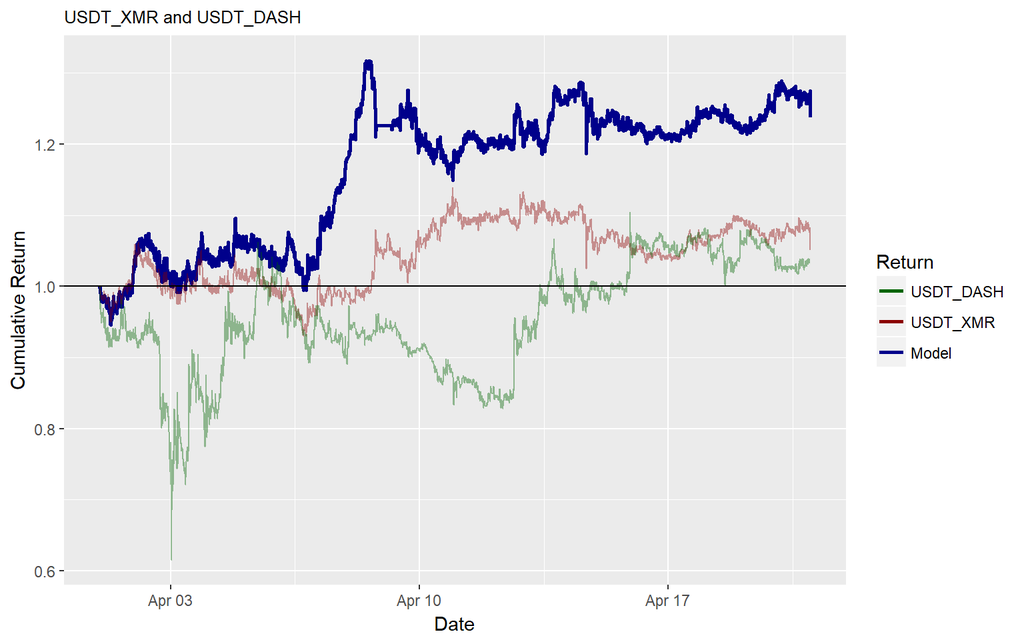

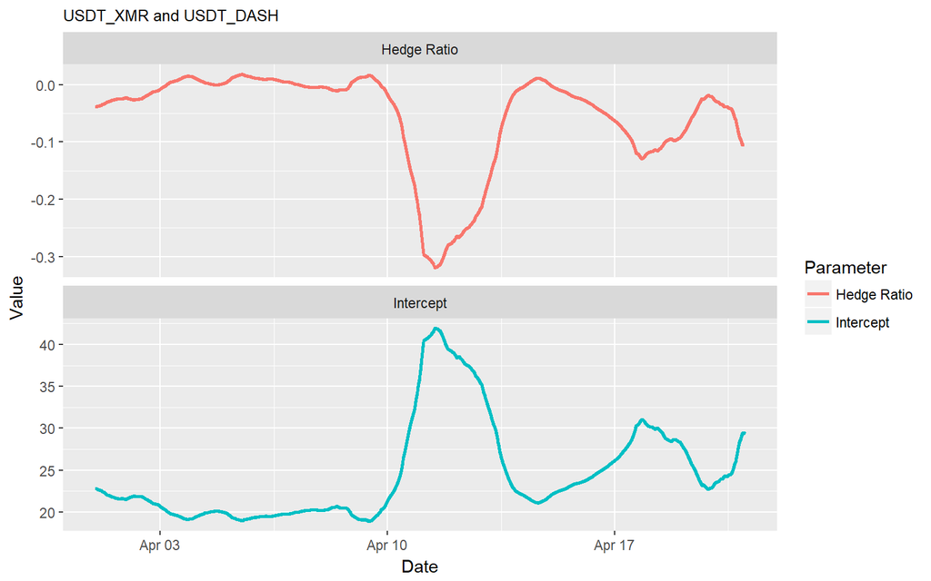

```
## [1] "Creating plot for overall strategy."
```

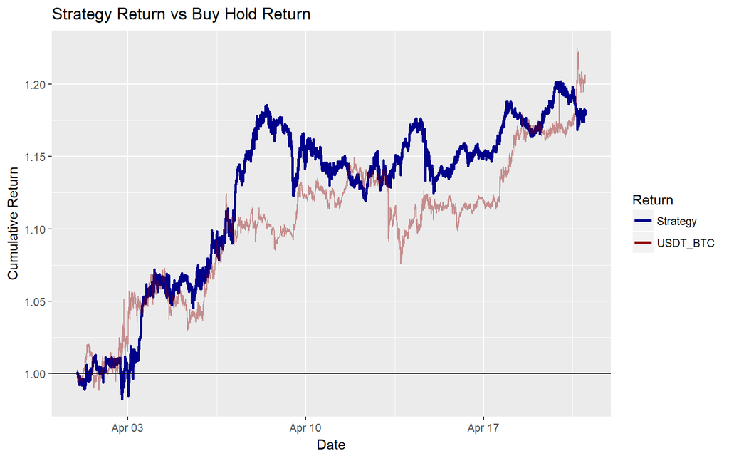

```r
plot_many(pricing_data = pricing_data,
          cutoff_date = "2017-04-01",
          params = params,
          number_pairs = number_pairs)
```

# 11. Cross Validation March 2017

```
## # A tibble: 9 x 3
##     coin_y    coin_x cointegration_stat
##      <chr>     <chr>              <dbl>
## 1 USDT_LTC  USDT_ZEC          -5.760345
## 2 USDT_LTC  USDT_XMR          -4.944385
## 3 USDT_LTC  USDT_ETH          -4.838984
## 4 USDT_LTC USDT_DASH          -4.653697
## 5 USDT_LTC  USDT_BTC          -4.550198
## 6 USDT_XMR  USDT_LTC          -4.252412
## 7 USDT_XMR  USDT_BTC          -4.148961
## 8 USDT_ZEC  USDT_LTC          -4.007311
## 9 USDT_XMR USDT_DASH          -4.005995
## [1] "Creating plots for USDT_LTC and USDT_ZEC."
## [1] "Using train set from 2017-01-30 to 2017-03-01."
## [1] "Using test set from 2017-03-01 to 2017-03-21."
```

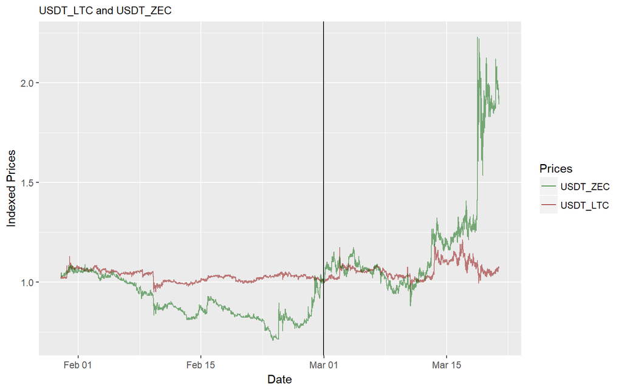

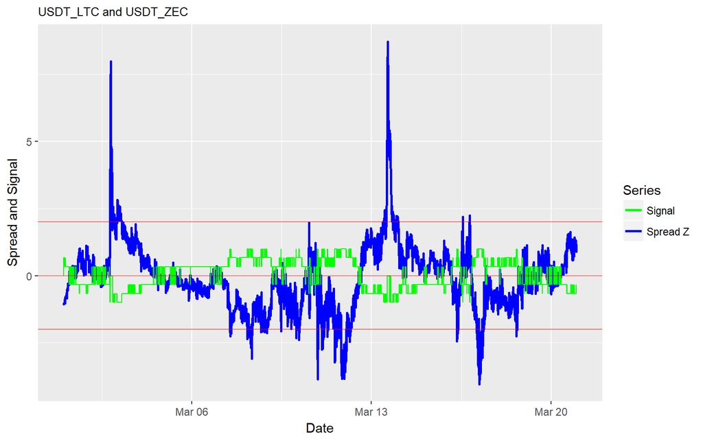

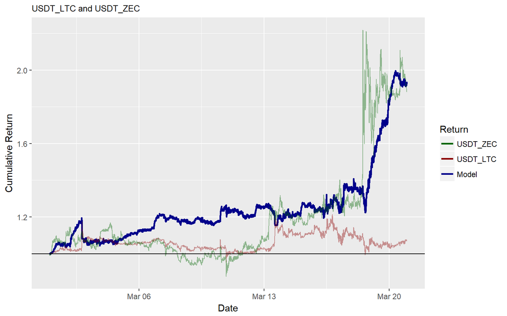

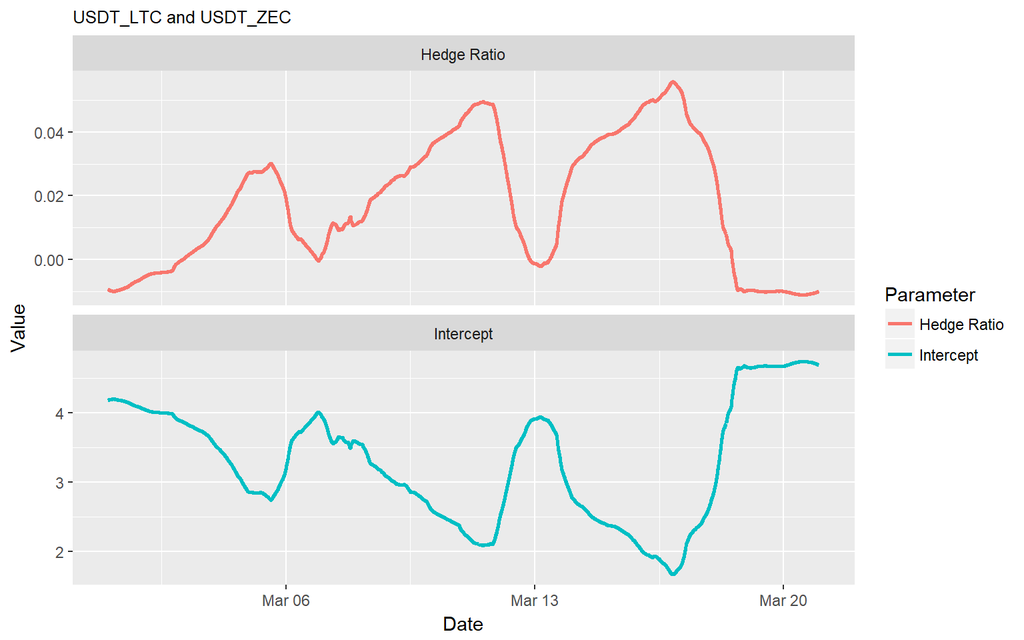

```
## [1] "Creating plot for overall strategy."
```

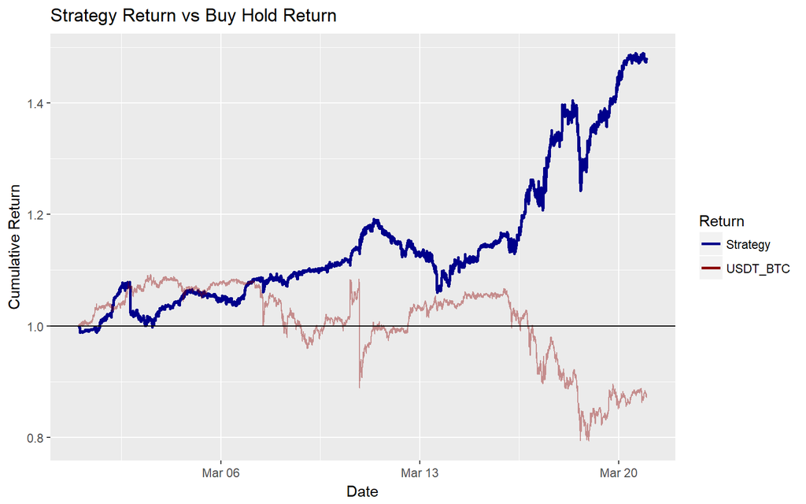

```r
plot_many(pricing_data = pricing_data,
          cutoff_date = "2017-03-01",
          params = params,
          number_pairs = number_pairs)
```